# CS-325-12

Matthew Brown

December 8, 2018

## Background

Drunk Driving is a major problem in the United States. Programs nation wide seek to curve it. We often hear stories of families being devestated by the irresponsibility of one person who is driving under the influence. One might suspect that there is a correlation between drunk driving and the time of day. One might also suspect that it is more likely to get into an accident if a driver is drunk over being sober.

## Test Data

Summarized 2015 Statistics on fatal car crashes by hour of day.

```
##    hour_of_crash drunk_drivers sober_drivers total_deaths
## 1              0           662           611         1400
## 2              1           727           502         1362
## 3              2           758           452         1329
## 4              3           533           412         1038
## 5              4           317           434          835
## 6              5           248           753         1068
## 7              6           206          1000         1312
## 8              7           162           986         1249
## 9              8            88           822          976
## 10             9            88           872         1029
## 11            10            93           926         1121
## 12            11           133           998         1256
## 13            12           131          1092         1343
## 14            13           189          1206         1522
## 15            14           205          1313         1659
## 16            15           269          1421         1846
## 17            16           329          1324         1825
## 18            17           441          1398         1993
## 19            18           524          1373         2049
## 20            19           545          1244         1940
## 21            20           592          1275         2010
## 22            21           641          1171         1962
## 23            22           607           956         1710
## 24            23           624           718         1473
```

## Plot

The following graphic would imply that there is a correlation between the time of day, and the number of drunk driving related fatalities. What’s interesting is that as we get more into the sleep hours, there is a greater number of drunk driving related fatalties. As we leave those hours, there are less fatalities.

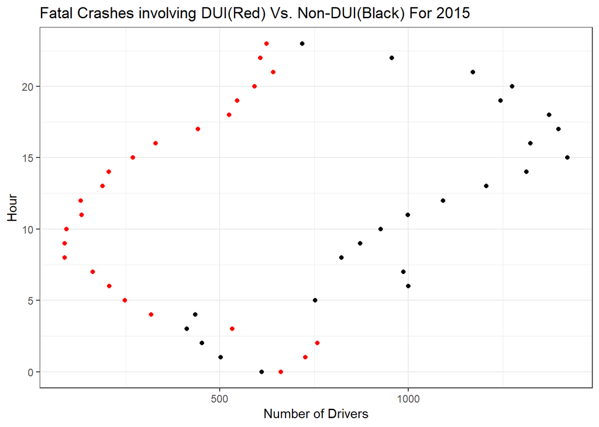

## Test results

```
##
##  Pearson's Chi-squared test
##
## data:  merged_data$drunk_drivers and merged_data$sober_drivers
## X-squared = 528, df = 506, p-value = 0.2411
```

[output not shown]

[output cut: 135 more lines]

## Interpretation

With a p-value of 0.2411, we do not reject the Null hypothesis. We come to the conclusion that the hour of the day and the soberness of the driver are not associated. However, because none of the expected counts are greater than 1, this data is not appropriate for any chi-squared test.